# Project 2.2

Oluwakemi Omotunde

October 09, 2016

## **Task**

#### *We are to choose any three of the “wide” datasets identified in the Week 5 Discussion items and for each:*

- *Create a .CSV file that includes all of the information included in the dataset. We’re encouraged to use a “wide” stucture similar to how th information appears in the discussion item, so we can practice tidying and transformations.*
- *Read the information from your .CSV file into R, and use tidyr and dplyr as needed to tidy and transform your data.*
- *Perform the analysis requested in the discussion item.*
- *Code should be in an R Markdown file, posted to rpubs.com, and should include narrative dscriptions of your dataa clean up work, analysis and conclusions.*

## **Introduction**

##### *For my second dataset, I decided to take a look at hospitals in the tri-state area(NY, NJ, CT). I would like to be able to determine which state has the best hospitals overall as well as which hosptals have the top ratings.*

## **Hypothesis**

### **Loading data and required libraries**

```
## [1] TRUE
```

```
##                                               NAME STATE COMM.NURSES
## 35                                BRISTOL HOSPITAL    CT           1
## 110                     CLARA MAASS MEDICAL CENTER    NJ           0
## 111 UNIV MEDICAL CENTER OF PRINCETON AT PLAINSBORO    NJ           0
## 112            VIRTUA WEST JERSEY HOSPITALS BERLIN    NJ           7
## 113                       RIVERVIEW MEDICAL CENTER    NJ           2
## 114        ROBERT WOOD JOHNSON UNIVERSITY HOSPITAL    NJ           1
##     COMM.DOCTORS RESPONSIVENESS PAIN.MAN COMM.MEDS ENVIRONMENT DISCHARGE
## 35             0              1        1         0           0         6
## 110            0              0        0         0           0         0
## 111            0              0        0         0           4         0
## 112            0              4        3         6           1         2
## 113            0              0        3         2           0         2
## 114            0              1        0         0           0         0
##     OVERALL HCAHPS.BASE HCAHPS.CON
## 35        0          10         16
## 110       0           3         13
## 111       3          11         17
## 112       4          28         19
## 113       1          13         18
## 114       1           5         14
```

##### *Before I can do anything mathematically, I need to change the columns from character to numeric. We include the parameter na.rm =TRUE to remove the NA’s since we don’t want them to affect our calculations.*

##### *I’ll be using the dplyr and plyr packages to change around our data.*

##### *I noticed that there were a few entires where all columns are 0’s. I would like to remove those entries.*

##### *I am now at the point whereby my data looks pretty good and I am able to do some analysis and calculations.*

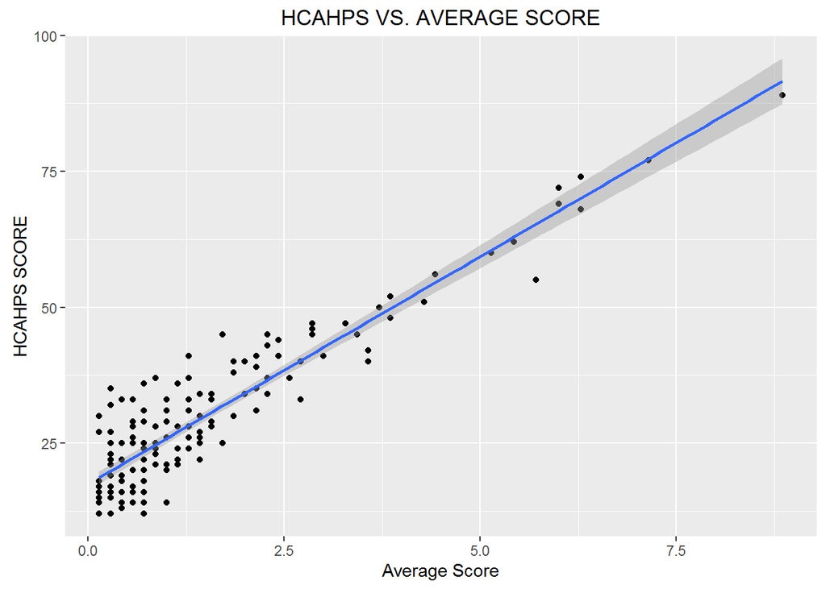

##### *Now to see which state has the best ratings overall.*

```
##   STATES AVERAGE
## 1     CT    1.92
## 2     NJ    1.20
## 3     NY    1.56
```

[interactive chart not shown]

```
##   STATES SCORE
## 1     CT 32.25
## 2     NJ 29.00
## 3     NY 30.30
```

[interactive chart not shown]

## *Conclusion*

We can conclude that Connecticut has the best hospitals in the Tri-State area based on both customer feedback as well as HCAHPS ratings. The best hospital in the Tri-State area is ADIRONDACK MEDICAL CENTER with a HCAHPS score of 89 out of 100 and an average rating of 8.86 out of 10.